# Taller 1 Corte 2 Estadística Matemática

Mateo Gomez Rojas, Miguel Jaimes Leon, Miguel Lugo Cozzarelli, Mateo Molinares Tellez, Hector Sanjuan Fabregas

2025-03-21

## Punto 1

Una muestra aleatoria de seis autos de un determinado modela evidencia que cada uno de ellos consume las siguientes cantidades en kms por litro:

18.6, 18.4, 19.4, 20.4, 19.4, 20.5

Determine la probabilidad de que el consumo de gasolina medio muestral sea menor que 17.6 kms por litro, suponiendo que la distribución poblacional es normal con media 17

### Datos

Unidad experimental: Carros

Población: Consumo de gasolina en kms/litro

Parametro: Media Poblacional mu = 17

Estadístico: Media muestral

Tamaño muestra: n = 6

Tamaño población: Desconocido

### Verificación de los supuestos

- Población con distribución normal
- Varianza poblacional desconocida
- Tamaño de la muestra pequeño n = 6

### Conclusión

La distribución muestral de la media es la t de student con n-1 grados de libertad

### Cálculo

```r
muestra <- c(18.6, 18.4, 19.4, 20.4, 19.4, 20.5)

x_hat <- mean(muestra)

S <- sd(muestra)

t <- (17.6 - 17)/(S/sqrt(length(muestra)))

pt(t, length(muestra) - 1)
```

```
## [1] 0.9229201
```

### Conclusiones

Tenemos un 92.3% de certeza de que al tomar una muestra aleatoria de 6 carros (sin reemplazo), obtendremos una media muestral de consumo de combustible menor a 17.6 kms/litro

## Punto 2

Se desea estudiar una muestra de 20 personas para saber la proporción de ellas que tiene más de 40 años. Sabiendo que la proporción en la población es del 40%, ¿cuál es la probabilidad de que la proporción en la muestra sea menor del 50%?

### Datos

Unidad experimental:personas.  
Población: Cantidad de personas que tienen mas de 40 años.  
Parametro: la proporcion poblacional (p) de la cantidad de personas que tienen mas de 40 años.  
Estadístico: la proporcion muestral($\hat{p}$) de la cantidad de personas que tienen mas de 40 años.  
Tamaño de la muestra: 20.  
Tamaño de la poblacion: desconocida.  
Otros datos

```r
p=0.40
n=20
```

### Comprobacion de supuestos

```r
print(n*p)
```

```
## [1] 8
```

```r
print(n*(1-p))
```

```
## [1] 12
```

El tamaño de la muestra es $n=20$ el cual es pequeño  
se cumple que $np=8\geq5$ y $n(1-p)=12\geq5$

### Conclusión de los supuestos

la distribucion muestral para la proporcion en la muestra es la distribución normal.

### Calculo

Queremos encontrar la probabilidad de que $P(\hat{p}<0.50)$. Al cumplirse los supuestos de $np\geq5$ y $n(1-p)\geq5$ se valida el teorema central del limite de Moivre-Laplace. En consecuencia se va a encontrar el valor de z que debe estar entre $(0,1)$

```r
desviacion <- sqrt(p * (1-p) / n)
p_m=0.50
z=(p_m - p) / desviacion
print(z)
```

```
## [1] 0.9128709
```

El valor de z encontrado es $z=0.9129$ por lo que se utilizara para encontrar la probabilidad de $\hat{p}$

```r
pz=pnorm(z)
print(pz)
```

```
## [1] 0.8193448
```

### Conclusión

se ha encontrado que $P(\hat{p}<0.50)=P(Z<0.9129)=0.8193$. con un 81.93% de certeza, podemos afirmar que en una muestra aleatoria de 20 personas la proporcion de las personas que tienen mas de 40 años sera menor que el 50%.

## Punto 3

Una empresa ha recibido 120 solicitudes de trabajo por parte de estudiantes que acaban de terminar su carrera de administración de empresas. Considerando estas solicitudes como una muestra aleatoria de todos los licenciados, ¿cuál es la probabilidad de que entre un 35% y un 45% de las solicitudes correspondan a mujeres si se sabe que el 40% de los administradores de empresas recién graduados lo son?

### Datos

- Unidad experimental: Solicitudes de trabajo.
- Población: Administradores de empresas recién graduados.
- Parámetro: Proporción poblacional de mujeres, $p = 0.4$.
- Estadístico: Proporción muestral, $\hat{p}$.
- Tamaño de la muestra: $n = 120$.

### Verificación de supuestos

Comprobamos que se cumplen los criterios para aproximar la distribución binomial con una normal:

```r
n <- 120
p <- 0.4
np <- n * p
nq <- n * (1 - p)
np; nq
```

```
## [1] 48
```

```
## [1] 72
```

Si ambos valores son mayores o iguales a 5, la distribución normal es una buena aproximación.

### Cálculo

Calculamos la media y la desviación estándar de la distribución normal aproximada:

```r
mu <- n * p
sigma <- sqrt(n * p * (1 - p))

lim_inf <- 0.35 * n
lim_sup <- 0.45 * n

z_inf <- (lim_inf - mu) / sigma
z_sup <- (lim_sup - mu) / sigma

prob <- pnorm(z_sup) - pnorm(z_inf)
prob
```

```
## [1] 0.7364475
```

### Conclusión

La probabilidad de que entre el 35% y el 45% de las solicitudes correspondan a mujeres es aproximadamente 0.7364, es decir, alrededor del 73.64%.

## Simulación 1

Se cargan los datos con los que vamos a realizar la simulación y se toman mu y sigma poblacionales (asumimos sigma conocido)

```r
dataset<- read.csv("C:/Users/hecto/OneDrive/Escritorio/R/estMat/dataset.csv", sep=";")
mudata=mean(dataset$age)
sigma=sd(dataset$age)
```

Creamos 1000 muestras aleatorias para la simulación, de tamaño 20

```r
n=20
M=1000
set.seed(2812)

z=rep(NA,M)

for (i in 1:M){
  x= sample(dataset$age,n)
  xbarra=mean(x)
  z[i]=(xbarra-mudata)/(sigma/sqrt(n))
}
```

Con la libreria ggplot2 creamos el histograma del estadístico z , y luego lo comparamos con el estadístico tabulado, una distribución normal estándar.

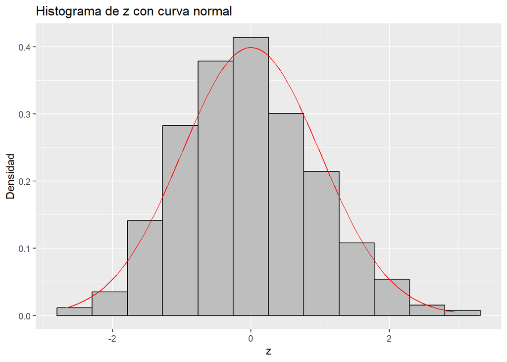

```r
library(ggplot2)

df<-data.frame(z=z)

ggplot(df, aes(x = z)) +
  geom_histogram(aes(y = ..density..), bins = 12, fill = "gray", color = "black") +
  stat_function(fun = dnorm, args = list(mean = 0, sd = 1), color = "red") +
  labs(title = "Histograma de z con curva normal", x = "z", y = "Densidad")
```

Otra forma de comparar la distribución del estadístico z con la distribución normal:

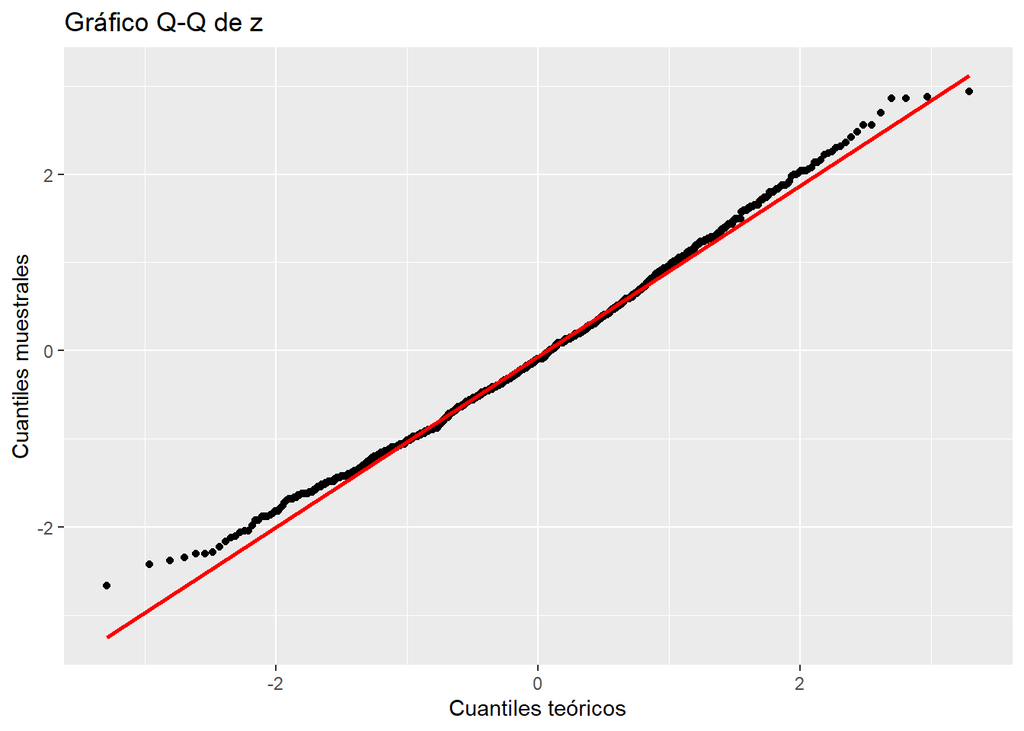

```r
ggplot(df, aes(sample = z)) +
  stat_qq() +  #qqplot
  stat_qq_line(color = "red", linewidth = 1) + #qqline
  labs(title = "Gráfico Q-Q de z", x = "Cuantiles teóricos", y = "Cuantiles muestrales")
```

Pruebas de normalidad

```r
library(nortest) #para el lillie.test
ks.test(z, 'pnorm')
```

```
##
##  Asymptotic one-sample Kolmogorov-Smirnov test
##
## data:  z
## D = 0.050426, p-value = 0.01237
## alternative hypothesis: two-sided
```

```r
lillie.test(z)
```

```
##
##  Lilliefors (Kolmogorov-Smirnov) normality test
##
## data:  z
## D = 0.033035, p-value = 0.01205
```

```r
shapiro.test(z)
```

```
##
##  Shapiro-Wilk normality test
##
## data:  z
## W = 0.99435, p-value = 0.0008226
```

Usamos fit.cont para ver a qué distribuciones se ajusta el estadístico z

```r
library(rriskDistributions)
fit.cont(z)
```

```
##
## Begin fitting distributions ---------------------------------------
```

```
## * fitting normal distribution ... OK
```

```
## * fitting Cauchy  distribution ... OK
```

```
## * fitting logistic distribution ... OK
```

```
## * fitting beta distribution ... failed
```

```
## * fitting exponential distribution ... failed
```

```
## * fitting chi-square distribution ... failed
```

```
## * fitting uniform distribution ... OK
```

```
## * fitting gamma distribution ... failed
```

```
## * fitting lognormal distribution ... failed
```

```
## * fitting Weibull distribution ... failed
```

```
## * fitting F-distribution ... failed
```

```
## * fitting Student's t-distribution ... OK
```

```
## * fitting Gompertz distribution ... failed
```

```
## * fitting triangular distribution ... failed
```

```
## End fitting distributions -----------------------------------------
```

```
##              logL     AIC     BIC Chisq(value) Chisq(p) AD(value)    H(AD)
## Normal   -1385.44 2774.88 2784.69        35.13     0.05      1.38 rejected
## Cauchy    -1570.8 3145.59 3155.41       272.75     0.00     14.26 rejected
## Logistic -1397.28 2798.56 2808.37        45.98     0.00      1.84 rejected
## Uniform      NULL    NULL    NULL          Inf     0.00       Inf     NULL
## Student  -1388.14 2778.28 2783.19        40.98     0.02      3.41     NULL
##          KS(value)        H(KS)
## Normal        0.03 not rejected
## Cauchy        0.09     rejected
## Logistic      0.03 not rejected
## Uniform       0.07     rejected
## Student       0.05     rejected
```

```
##
## Chosen continuous distribution is: Normal (norm)
## Fitted parameters are:
##        mean          sd
## -0.04468813  0.96705444
```

Para esta semilla, el estadístico z sigue una distribución normal con parámetros:

media=-0.04468813 y desviación estándar=0.96705444

## Simulación 2

Se cargan los datos con los que vamos a realizar la simulación y se toma mu poblacional (sigma desconocido)

```r
dataset<- read.csv("C:/Users/hecto/OneDrive/Escritorio/R/estMat/dataset.csv", sep=";")
mudata=mean(dataset$age)
```

Creamos 1000 muestras aleatorias para la simulación, de tamaño 20

```r
n=20
M=1000
set.seed(2812)

z=rep(NA,M)

for (i in 1:M){
  x= sample(dataset$age,n)
  xbarra=mean(x)
  s=sd(x)
  z[i]=(xbarra-mudata)/(s/sqrt(n))
}
```

Con la libreria ggplot2 creamos el histograma del estadístico z , y luego lo comparamos con el estadístico tabulado, una distribución normal estándar.

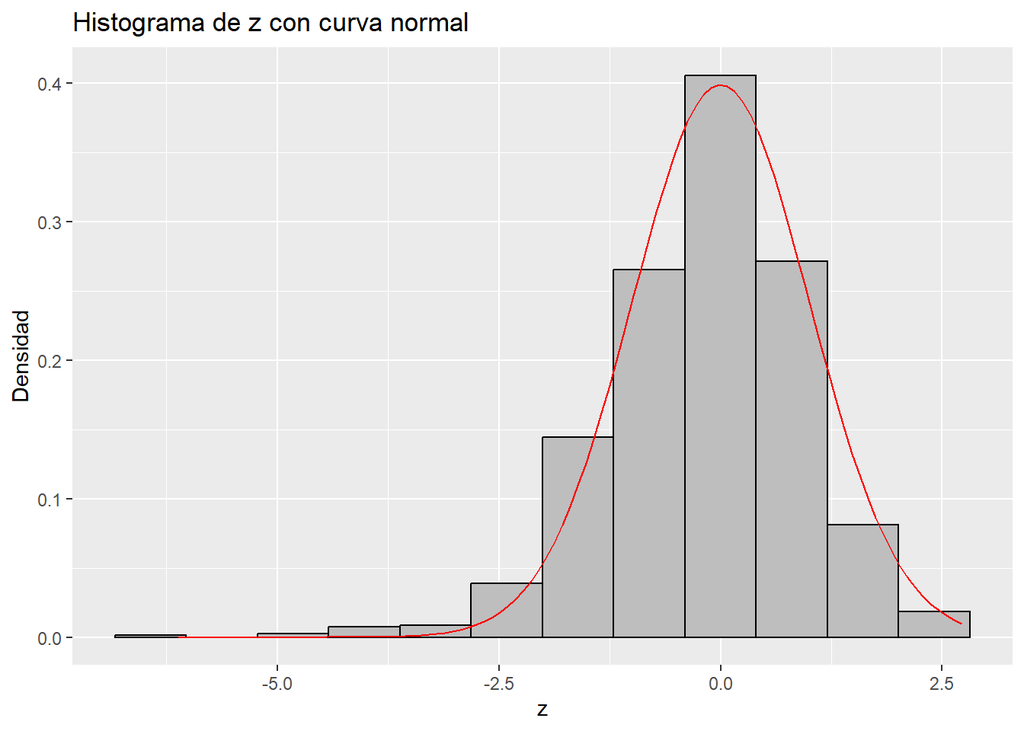

```r
library(ggplot2)

df<-data.frame(z=z)

ggplot(df, aes(x = z)) +
  geom_histogram(aes(y = ..density..), bins = 12, fill = "gray", color = "black") +
  stat_function(fun = dnorm, args = list(mean = 0, sd = 1), color = "red") +
  labs(title = "Histograma de z con curva normal", x = "z", y = "Densidad")
```

Otra forma de comparar la distribución del estadístico z con la distribución normal:

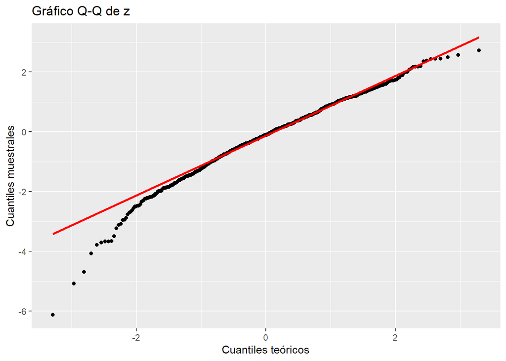

```r
ggplot(df, aes(sample = z)) +
  stat_qq() +  #qqplot
  stat_qq_line(color = "red", linewidth = 1) + #qqline
  labs(title = "Gráfico Q-Q de z", x = "Cuantiles teóricos", y = "Cuantiles muestrales")
```

Pruebas de normalidad:

```r
library(nortest) #para el lillie.test
ks.test(z, 'pnorm')
```

```
##
##  Asymptotic one-sample Kolmogorov-Smirnov test
##
## data:  z
## D = 0.054315, p-value = 0.005478
## alternative hypothesis: two-sided
```

```r
lillie.test(z)
```

```
##
##  Lilliefors (Kolmogorov-Smirnov) normality test
##
## data:  z
## D = 0.04546, p-value = 4.698e-05
```

```r
shapiro.test(z)
```

```
##
##  Shapiro-Wilk normality test
##
## data:  z
## W = 0.97952, p-value = 1.177e-10
```

Usamos fit.cont para ver a qué distribuciones se ajusta el estadístico z

```r
library(rriskDistributions)
fit.cont(z)
```

```
##
## Begin fitting distributions ---------------------------------------
```

```
## * fitting normal distribution ... OK
```

```
## * fitting Cauchy  distribution ... OK
```

```
## * fitting logistic distribution ... OK
```

```
## * fitting beta distribution ... failed
```

```
## * fitting exponential distribution ... failed
```

```
## * fitting chi-square distribution ... failed
```

```
## * fitting uniform distribution ... OK
```

```
## * fitting gamma distribution ... failed
```

```
## * fitting lognormal distribution ... failed
```

```
## * fitting Weibull distribution ... failed
```

```
## * fitting F-distribution ... failed
```

```
## * fitting Student's t-distribution ... OK
```

```
## * fitting Gompertz distribution ... failed
```

```
## * fitting triangular distribution ... failed
```

```
## End fitting distributions -----------------------------------------
```

```
##              logL     AIC     BIC Chisq(value) Chisq(p) AD(value)    H(AD)
## Normal   -1507.31 3018.61 3028.43        42.23     0.02      2.78 rejected
## Cauchy   -1639.79 3283.58 3293.39       237.97     0.00     12.49 rejected
## Logistic -1494.31 2992.62 3002.44        40.91     0.02      1.40 rejected
## Uniform      NULL    NULL    NULL          Inf     0.00       Inf     NULL
## Student  -1501.37 3004.74 3009.64        52.83     0.00      8.54     NULL
##          KS(value)        H(KS)
## Normal        0.05     rejected
## Cauchy        0.08     rejected
## Logistic      0.03 not rejected
## Uniform       0.09     rejected
## Student       0.05     rejected
```

```
##
## Chosen continuous distribution is: Logistic (logis)
## Fitted parameters are:
##   location      scale
## -0.1254674  0.6052705
```

Para esta semilla, el estadístico z sigue una distribución logística con parámetros: